# Lab 10 - Final - Multiple Linear Regression

Crystal Bae

12/2/2019

### Objectives

- Multiple linear regression
- Check assumptions w/ diagnostic plots
- Make predictions for MLR with new data
- Intro to maps / spatial analysis in R & gganimate

### Multiple Linear Regression

```r
homes <- read_csv("slo_homes.csv") %>%
  janitor::clean_names() %>%
  filter(city %in% c("San Luis Obispo", "Atascadero", "Arroyo Grande"))
```

Look at correlations between numeric variables (checking to see if we think collinearity might be a concern). Ignore price_per_sq_ft since it’s a calculated metric.

```r
# Creates correlation matrix:
homes_cor <- cor(homes[2:6])
homes_cor
```

```
##                     price    bedrooms bathrooms     sq_ft price_per_sq_ft
## price           1.0000000  0.31152578 0.4991453 0.6618575      0.73664029
## bedrooms        0.3115258  1.00000000 0.7519186 0.6960233     -0.09994633
## bathrooms       0.4991453  0.75191865 1.0000000 0.8046112      0.07624770
## sq_ft           0.6618575  0.69602326 0.8046112 1.0000000      0.12549708
## price_per_sq_ft 0.7366403 -0.09994633 0.0762477 0.1254971      1.00000000
```

Make a correlogram (plot of correlations):

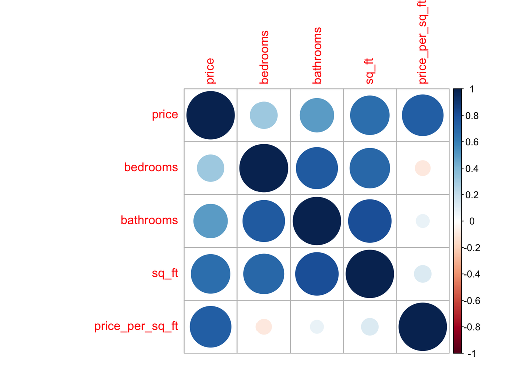

```r
corrplot(homes_cor)
```

```r
beep(2)
```

Start with a complete model including all variables for now:

```r
# linear model with outcome as price (assumes no interaction)
home_lm <- lm(price ~ city + bedrooms + bathrooms + sq_ft + status,
              data = homes)
home_lm
```

```
##
## Call:
## lm(formula = price ~ city + bedrooms + bathrooms + sq_ft + status,
##     data = homes)
##
## Coefficients:
##         (Intercept)       cityAtascadero  citySan Luis Obispo
##            184130.9            -167396.4              31018.1
##            bedrooms            bathrooms                sq_ft
##           -161645.5              48692.0                389.1
##       statusRegular     statusShort Sale
##            303964.6             -19828.6
```

Let’s interpret the model results.

- Since Atascadero and SLO show up in the model, the reference level is Arroyo Grande.
- With all else held equal, we would expect a home in Atascadero to sell $167,396 dollars LESS than a home in Arroyo Grande, on average.
- With all else held equal, a house in SLO would sell for $31,018 MORE than a home in Arroyo Grande.
- This model also suggests that for each additional bedroom, on average home price decreases by $161,645 for each additional bedroom. This is non-sensical, so think about collinearity! Might be explaining the same thing (home price) with highly-correlated variables. It’s also treating the categorical variable of bedrooms as a continuous variable.

(Tip: A good guideline is at least 20 samples on each variable level you include in the regression.)

```r
home_lm2 <- lm(price ~ city + sq_ft + status,
               data = homes)
home_lm2
```

```
##
## Call:
## lm(formula = price ~ city + sq_ft + status, data = homes)
##
## Coefficients:
##         (Intercept)       cityAtascadero  citySan Luis Obispo
##             -105821              -182587                70279
##               sq_ft        statusRegular     statusShort Sale
##                 325               315441                31284
```

On average, home price increases by $325 for every 1 sq ft increase in home size. (This is still pretty pricey, but makes sense for the central coast.)

AIC values: This tells you about the balance between model fit and model complexity. Better model fit indicated by lower AIC value.

```r
AIC(home_lm) # values not meaningful on their own, but useful in comparison...
```

```
## [1] 3576.834
```

```r
AIC(home_lm2)
```

```
## [1] 3584.3
```

```r
# Be careful: AIC is not useful on its own! Consider your conceptual evidence from your interpretation of the data.
```

Let’s check out the adjusted R-squared value to see model fit.

```r
summary(home_lm) # don't throw out coefficients based on significance alone!
```

```
##
## Call:
## lm(formula = price ~ city + bedrooms + bathrooms + sq_ft + status,
##     data = homes)
##
## Residuals:
##     Min      1Q  Median      3Q     Max
## -843938 -115963  -12298  109718 3445077
##
## Coefficients:
##                       Estimate Std. Error t value Pr(>|t|)
## (Intercept)          184130.93  143368.84   1.284  0.20157
## cityAtascadero      -167396.39   78701.95  -2.127  0.03552 *
## citySan Luis Obispo   31018.14  114895.10   0.270  0.78766
## bedrooms            -161645.51   49414.32  -3.271  0.00141 **
## bathrooms             48692.04   52408.63   0.929  0.35476
## sq_ft                   389.12      53.17   7.318 3.43e-11 ***
## statusRegular        303964.64  105942.81   2.869  0.00488 **
## statusShort Sale     -19828.56   86335.35  -0.230  0.81875
## ---
## Signif. codes:  0 '***' 0.001 '**' 0.01 '*' 0.05 '.' 0.1 ' ' 1
##
## Residual standard error: 380600 on 117 degrees of freedom
## Multiple R-squared:  0.5682, Adjusted R-squared:  0.5424
## F-statistic:    22 on 7 and 117 DF,  p-value: < 2.2e-16
```

```r
summary(home_lm2) # simpler model, with coefficients that make sense, but slightly smaller adjusted R-squared
```

```
##
## Call:
## lm(formula = price ~ city + sq_ft + status, data = homes)
##
## Residuals:
##     Min      1Q  Median      3Q     Max
## -653118 -120914   -8844  101402 3644738
##
## Coefficients:
##                       Estimate Std. Error t value Pr(>|t|)
## (Intercept)         -105820.71  118697.40  -0.892   0.3745
## cityAtascadero      -182586.90   80683.44  -2.263   0.0254 *
## citySan Luis Obispo   70278.97  115846.31   0.607   0.5452
## sq_ft                   325.03      31.54  10.306   <2e-16 ***
## statusRegular        315441.26  109749.65   2.874   0.0048 **
## statusShort Sale      31284.44   87356.11   0.358   0.7209
## ---
## Signif. codes:  0 '***' 0.001 '**' 0.01 '*' 0.05 '.' 0.1 ' ' 1
##
## Residual standard error: 395100 on 119 degrees of freedom
## Multiple R-squared:  0.5268, Adjusted R-squared:  0.5069
## F-statistic: 26.49 on 5 and 119 DF,  p-value: < 2.2e-16
```

Let’s ask `stargazer` package to create the summary regression table for us! Such a nightmare by hand.

```r
# results 'asis' because stargazer outputs to HTML already

stargazer(home_lm, home_lm2, type = "html")
```

|  | *Dependent variable:* |  |
| --- | --- | --- |
|  | price |  |
|  | (1) | (2) |
| cityAtascadero | -167,396.400** | -182,586.900** |
|  | (78,701.950) | (80,683.440) |
| citySan Luis Obispo | 31,018.140 | 70,278.970 |
|  | (114,895.100) | (115,846.300) |
| bedrooms | -161,645.500*** |  |
|  | (49,414.320) |  |
| bathrooms | 48,692.040 |  |
|  | (52,408.630) |  |
| sq_ft | 389.120*** | 325.028*** |
|  | (53.171) | (31.538) |
| statusRegular | 303,964.600*** | 315,441.300*** |
|  | (105,942.800) | (109,749.700) |
| statusShort Sale | -19,828.560 | 31,284.440 |
|  | (86,335.350) | (87,356.110) |
| Constant | 184,130.900 | -105,820.700 |
|  | (143,368.800) | (118,697.400) |
| Observations | 125 | 125 |
| R<sup>2</sup> | 0.568 | 0.527 |
| Adjusted R<sup>2</sup> | 0.542 | 0.507 |
| Residual Std. Error | 380,586.300 (df = 117) | 395,084.400 (df = 119) |
| F Statistic | 21.997*** (df = 7; 117) | 26.491*** (df = 5; 119) |
| *Note:* | p<0.1; p<0.05; p<0.01 |  |